# 都市間立地

岩田真一郎（神奈川大学経済学部）

2025-11-04作成，2026-09-19改訂

［PDF形式：545KB］

日本では，東京都を中心とする東京圏への人口集中が続いています．図1からは，三大都市圏のうち東京圏だけが顕著な転入超過を維持していることがわかります．

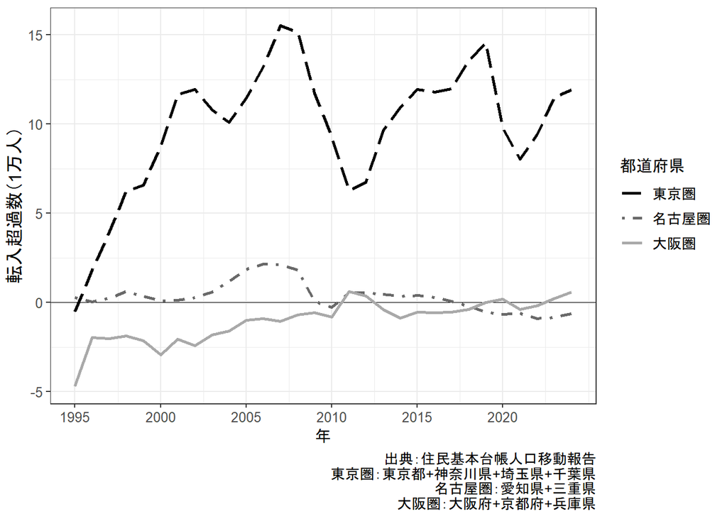

図1：転入超過数の推移

人々は経済的に豊かになろうと考え，賃金や所得の高い東京圏へ移動します．しかし，賃金・所得の上昇による利益は，住宅獲得競争による家賃や住宅価格の上昇によって相殺されます．図2に示すように，賃金の高い都道府県ほど家賃も高い傾向にあります．[^1]

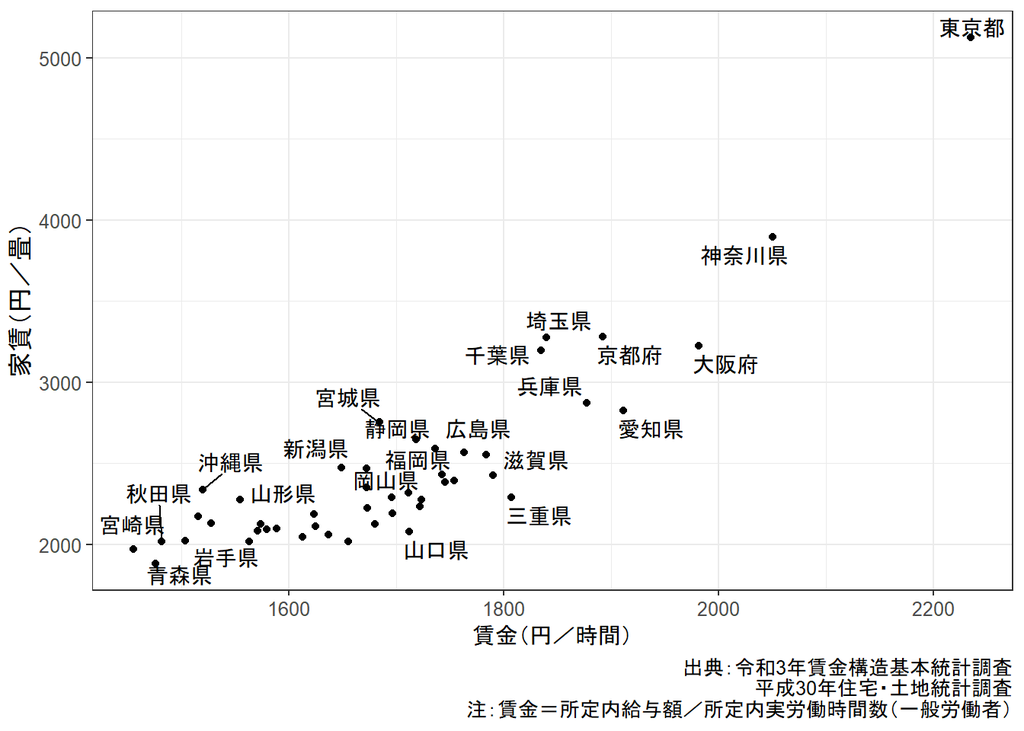

図2：都道府県の家賃と賃金の散布図

このため，所得から住宅費を差し引いた可処分所得は，全国でおおむね均一化してゆきます．ただし，実際には誤差が生じ，完全に等しくなるわけではありません．国土交通省はこの差に注目し，「[都道府県別の経済的豊かさ（可処分所得と基礎支出）](https://www.mlit.go.jp/policy/shingikai/content/001389727.pdf)」を公表しました．これによると，東京都の経済的豊かさは，驚くことに全国最下位でした．それでは，なぜ最下位の東京都を含む東京圏への人口流入が続くのでしょうか？

この事実は，人々の移動や立地を経済的豊かさの追求だけで説明することの難しさを示しているのかもしれません．経済的豊かさの追求の他に考えられるのは，緑や水辺のある公園，整備された道路，充実した教育施設，多様な文化施設といった，市場で取引しづらい**非経済的豊かさ**の追求です．この都市固有の非経済的豊かさは**都市アメニティ**とよばれます．

そこで，本稿の第1節では，**ローバック**が開発した家賃，賃金，都市アメニティを考慮した家計と企業の都市間立地を説明する**ローバックモデル**について紹介します[^2]<sup>,</sup> [^3]．第2節では，実際のデータを用いて，都市アメニティの価値を計算し，都市の順位を求めます.

# 1 理論

## 1.1 家計

最初に家計の都市間立地を考えます．家計（消費者）の満足，**効用**，は家賃r，賃金w，都市アメニティaの水準に依存し，家賃は低い方が，賃金と都市アメニティは高い方が，効用は高くなるとします．図3には，都市アメニティの水準がa<sub>1</sub>である都市1に立地したときの**無差別曲線**V<sub>1</sub>が示されています．無差別曲線は家計の効用が等しくなるような家賃と賃金の組み合わせを結んだ曲線です．ここで，無差別曲線が**右上がり**になるのは，賃金が高くなると，効用を一定に保つように高い家賃を家計が受け入れることを意味します．もしも，賃金が高くなったときに，家賃が低くなると，効用が高まりますので，無差別曲線は右下がりにはなりません．ここで，V<sub>1</sub>の下付の1は都市アメニティがa<sub>1</sub>の下での無差別曲線であることを示しています．なお，図3には無差別曲線V<sub>1</sub>がVに等しいと示されていますが，これは効用水準がVであることを意味します．

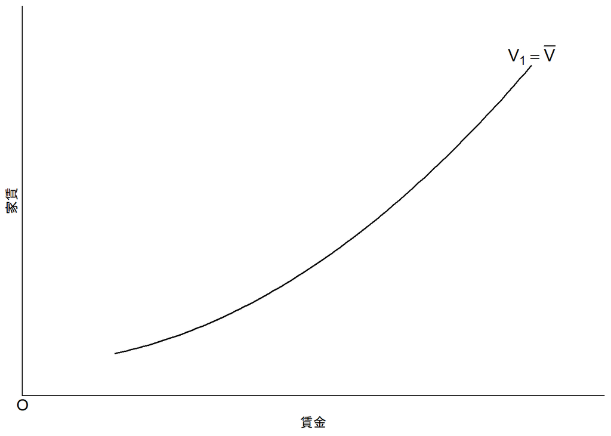

図3：都市1の立地と無差別曲線

都市2の都市アメニティの水準は都市1より高いa<sub>2</sub>であるとします．仮に，都市2の家賃と賃金が都市1と等しければ，都市2に立地した方が消費者の効用は高くなります．この結果，都市1に立地する家計の中には都市2への移動を考えるものが現れ，実際に移動し始めます．それでは，このような都市間移動はいつまで続くでしょうか．それは，都市2に立地したときの効用が都市1に立地したときの効用に等しくなるまでです．この状態では，都市1から都市2に立地点を変更するうまみがありません．家計が都市間移動を通じて効用を高めれれない状況が均衡になり，これを**立地均衡**（または**空間均衡**）とよびます．このとき，都市2では，家賃が都市1より高くなっているか，賃金が都市1より低くなっているかのいずれかが起きているか，両方が起きているはずです．なぜなら，例え都市2のアメニティが良くても，その良さを相殺するように家賃が高かったり，賃金が低かったりすれば，家計は都市1に留まっても良いと考えるからです．

図4には，都市1に立地したときの無差別曲線に加え，都市2に立地したときの無差別曲線も描かれています．上で述べたように，都市2の無差別曲線は，都市1の無差別曲線に比べて上方（左方，左上）に位置します．仮に同じ賃金であれば，都市アメニティの良さを反映して都市2の家賃は高くなります．家賃が等しければ，賃金が低くなります．注意しなくてはいけないのは，このような家賃，賃金の調整の結果，立地均衡においては，家計の効用は都市1に立地しても，都市2に立地しても等しくなることです．

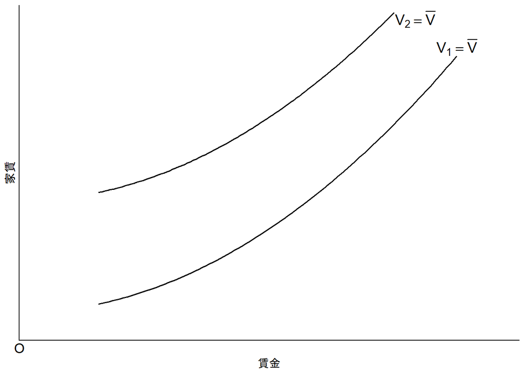

図4：家計の都市間立地

## 1.2 企業

次に企業の都市間立地を考えます．企業（生産者）の単位費用（生産物1単位あたりの費用）は不動産を借りる家賃r，労働者を雇う賃金w，生産活動に影響のある都市アメニティaの水準に依存し，家賃と賃金は低い方が，都市アメニティは高い方が，単位費用は低くなるとします．収入が与えられたとき，単位費用が等しければ，利潤は等しく保てます．仮に，財の価格が1であり，企業の利潤を0とすると，単位費用は1に等しくなります．

図5には，都市アメニティの水準がa<sub>1</sub>である都市1に立地したときの**等利潤曲線**C<sub>1</sub>=1が示されています．等利潤曲線は企業の利潤が等しくなる，今回の例では利潤が0になる，ような家賃と賃金の組み合わせを結んだ曲線です．ここで，等利潤曲線が**右下がり**になるのは，賃金が高くなったときに，家賃が低くならないと利潤を一定に保てないからです．ここで，C<sub>1</sub>の下付の1は都市アメニティがa<sub>1</sub>であることを意味します．

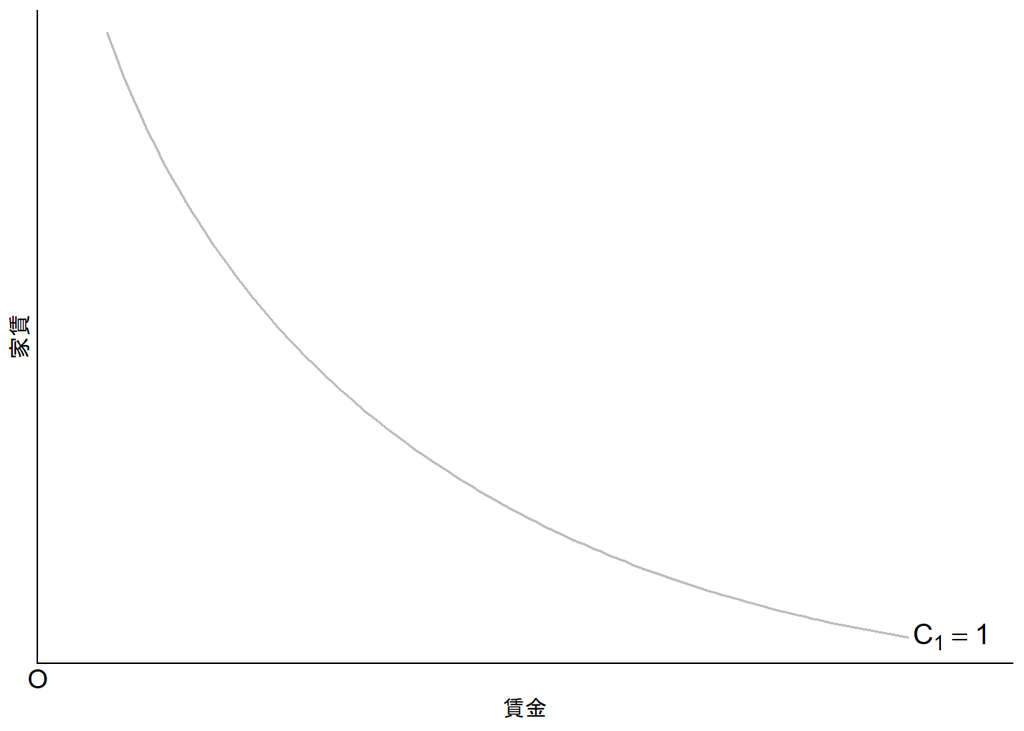

図5：都市1の立地と等利潤曲線

都市2の都市アメニティの水準は都市1より高いa<sub>2</sub>でした．仮に，都市2の家賃と賃金が都市1と等しければ，都市2に立地した方が企業の利潤は高くなります．この結果，都市1に立地する企業の中には都市2への移動を考えるものが現れ，実際に移動し始めます．それでは，このような都市間移動はいつまで続くでしょうか．それは，都市2に立地したときの利潤が都市1に立地したときの利潤に等しくなるまでです．この状態では，都市1から都市2に立地点を変更するうまみがありません．すなわち，企業側からみた立地均衡が成立している状態です．このとき，都市2では，家賃が都市1より高くなっているか，賃金が都市1より高くなっているかのいずれかが起きているか，両方が起きているはずです．なぜなら，例え都市2の都市アメニティが良くても，その良さを相殺するように不動産を借りる家賃が高かったり，労働者を雇う賃金が高かったりすれば，企業は都市1に留まっても良いと考えるからです．

図6には，都市1に立地したときの等利潤曲線に加え，都市2に立地したときの等利潤曲線も描かれています．上で述べたように，都市2の等利潤曲線は，都市1の等利潤曲線に比べて上方（右方，右上）に位置します．仮に同じ賃金であれば，都市アメニティの良さを反映して都市2の家賃は高くなります．家賃が等しければ，賃金が高くなります．注意しなくてはいけないのは，このような家賃，賃金の調整の結果，立地均衡においては，企業の利潤は都市1に立地しても，都市2に立地しても等しくなることです．

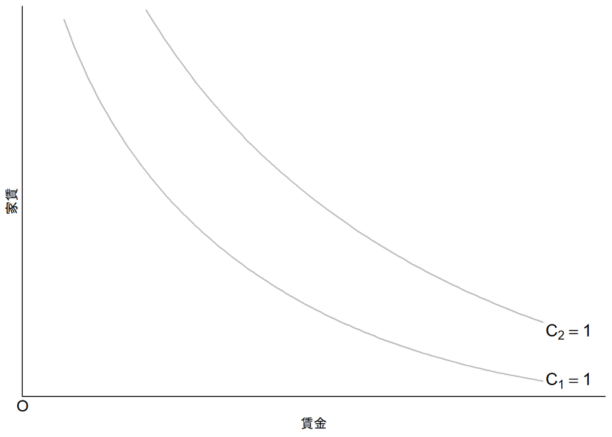

図6：企業の都市間立地

## 1.3 都市における家賃と賃金の決定

図3と図5を見てください．2つの図は，都市1に立地したときの効用（図3）または利潤（図5）を一定に保つ家賃と賃金の組み合わせを示していますが，それがどの水準に定まるかは教えてくれません．家賃と賃金の組み合わせは，家計の効用Vと企業の利潤0を同時に満たすように決定します．この条件を満たさないと，都市間移動の誘因が生じるためです．

そこで，図3に図5を重ねてみます（図7）．都市1の家賃と賃金は交点Aによって決まります．なぜなら，A点において，賃金w<sub>1</sub>を受け取り，家賃r<sub>1</sub>を支払う家計の効用はVを満たし，賃金w<sub>1</sub>，家賃r<sub>1</sub>を支払う企業の利潤は0を満たすからです．このとき，家計も企業も都市2への立地変更の誘因は生じません．

都市1において家賃と賃金の組み合わせがA点になることを，Z点と比較して考えてみましょう．Z点では，賃金はw<sub>1</sub>ですが，家賃はr<sub>1</sub>より高い水準にあります．したがって，家計の効用は低下し，企業の利潤も小さくなるため，家計と企業の一部が都市2へ移動し始めます．この過程で，家賃は低下してゆきます．この家賃低下は，家計と企業の都市間移動の誘因がなくなるまで続きますので，最終的に家賃はA点を満たすr<sub>1</sub>に落ち着きます．

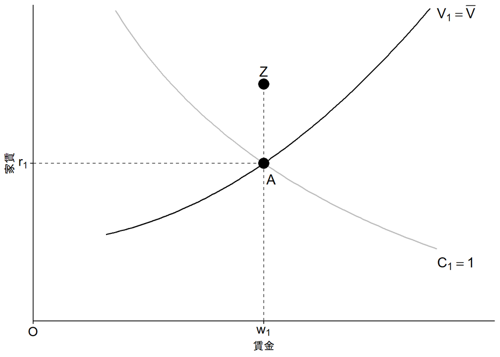

図7：都市1の家賃と賃金

## 1.4 都市1と都市2の比較

それでは，都市アメニティ水準が都市1に比べて高い都市2の家賃と賃金はどうなるでしょうか．都市2の無差別曲線は都市1に比べて上方に位置し，都市2の等利潤曲線も都市1に比べて上方に位置するため，家賃は都市2のほうが高くなります．賃金が高くなるか，低くなるかは，A点からの上方シフト幅に依存します．図8では，等利潤曲線の上方シフト幅が，無差別曲線の上方シフト幅より大きい場合を示しています．都市2の家賃と賃金はB点で決定します．したがって，都市アメニティ水準が都市1に比べて高い都市2の家賃と賃金は都市1に比べてどちらも高くなることがわかります．

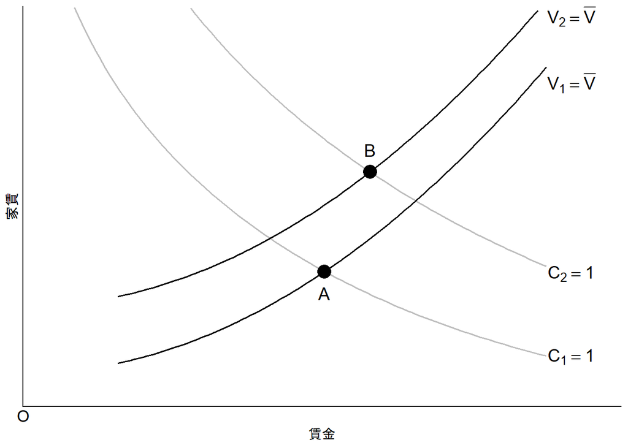

図8：都市間立地と家賃と賃金の比較

A点とB点は，家計と企業の立地均衡を同時に満たします．つまり，A点とB点において，家計の効用も，企業の利潤も等しくなっているため，都市間移動が生じません．このことは，賃金の高さを相殺するように家賃の高い都市2に立地した家計の効用が低いことを意味するわけではありません．[^4]家賃（と賃金）が高いのは，都市アメニティが充実しているからだと考えられます．

# 2 実証

## 2.1 推定式

$$家賃=\gamma_0+\gamma_1 賃金 +\epsilon\label{rent1}\tag{1}$$

$(\ref{rent1})$式では，賃金が時間あたり1円高い都市では，家賃は1畳あたり平均して$\gamma_1$円高いと解釈できます．つまり，$\gamma_1$は賃金と関係する家賃の部分を表します．一方で，$\epsilon$（誤差項）は賃金とは無関係な部分であり，グレイザーら（2001）はこの部分を用いて**都市アメニティの価値**を捉えようとしました．

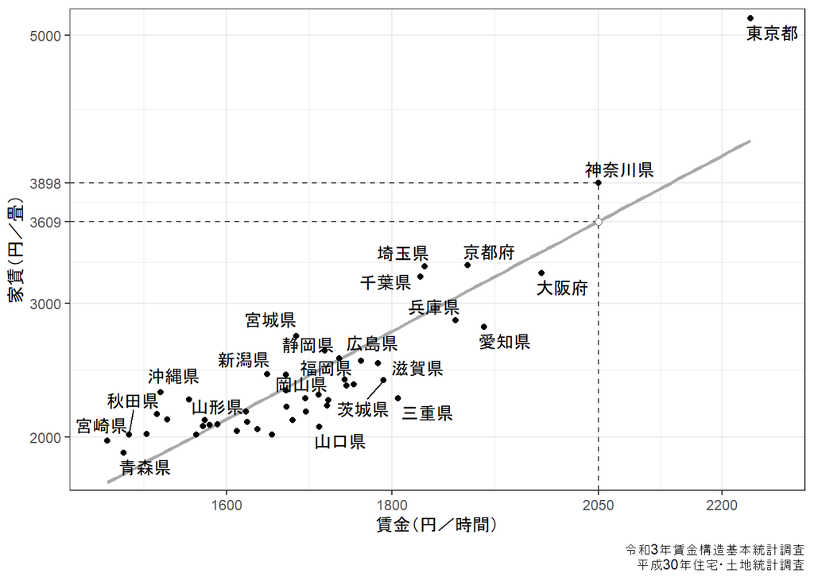

図9：近似線

例えば，神奈川県の1時間あたり賃金は2050円です．このとき，近似線上に対応する1畳あたり家賃は3609円になります．この値が2050円の賃金に対応する家賃の大きさ（**推定値**）です．しかし，実際に観察される家賃の大きさ（**観測値**）は1畳あたり3898円です．国土交通省の考えを借りると，神奈川県民は賃金に対応する家賃以上に家賃を支払っているため，経済的豊かさが低下します．しかし，グレイザーら（2001）は，この差こそ都市アメニティの価値であると考えました．家賃の観測値と家賃の推定値の差がこれにあたり，この部分を**残差**とよびます．実は，この残差が理論上の誤差項に相当します．したがって，神奈川県の場合，1畳あたりの家賃に含まれるアメニティの価値が289円ということになります．

このように考えると，賃金をある水準に固定して，観測される家賃が推定される家賃（近似線上で決定される家賃）よりも高い県は，残差が正になり，アメニティの価値が高いと解釈できます．家賃を高く払うのは都市アメニティの価値が高いからです．図9から，東京都のアメニティの価値が最も高いことが一目瞭然です．逆に，観測される家賃が推定される家賃よりも低い場合は，残差が負になり，アメニティの価値が低いと解釈できます．このように残差の値を計算することで，アメニティの価値に基づく都道府県順位を求めることができます．

## 2.2 都道府県順位

[最小二乗法](https://ja.wikipedia.org/wiki/%E6%9C%80%E5%B0%8F%E4%BA%8C%E4%B9%97%E6%B3%95)により$(\ref{rent1})$式を推定し，その後に残差を計算することで各都道府県のアメニティの価値を計算できます．表2がアメニティの価値に基づく都道府県の順位です．[^7]

表2：アメニティ価値の都道府県順位

| 順位 | 地域 | アメニティ価値 |
| --- | --- | --- |
| 1 | 東京都 | 913.005792 |
| 2 | 沖縄県 | 465.844158 |
| 3 | 埼玉県 | 355.459675 |
| 4 | 宮城県 | 343.726365 |
| 5 | 鳥取県 | 315.081295 |
| 6 | 宮崎県 | 312.077361 |
| 7 | 千葉県 | 294.672529 |
| 8 | 山形県 | 294.629064 |
| 9 | 神奈川県 | 288.144858 |
| 10 | 秋田県 | 270.459383 |
| 11 | 佐賀県 | 235.112815 |
| 12 | 岩手県 | 204.628905 |
| 13 | 京都府 | 190.374324 |
| 14 | 新潟県 | 178.109509 |
| 15 | 青森県 | 156.588406 |
| 16 | 静岡県 | 123.704092 |
| 17 | 岡山県 | 96.962385 |
| 18 | 大分県 | 79.275394 |
| 19 | 熊本県 | 43.593949 |
| 20 | 島根県 | 26.298860 |
| 21 | 福岡県 | 9.360062 |
| 22 | 鹿児島県 | 3.145966 |
| 23 | 長崎県 | -1.159117 |
| 24 | 富山県 | -20.037615 |
| 25 | 福島県 | -20.869800 |
| 26 | 広島県 | -98.891027 |
| 27 | 徳島県 | -99.824560 |
| 28 | 愛媛県 | -127.276951 |
| 29 | 福井県 | -148.014994 |
| 30 | 大阪府 | -157.062265 |
| 31 | 山梨県 | -157.155452 |
| 32 | 石川県 | -170.391123 |
| 33 | 兵庫県 | -171.432106 |
| 34 | 群馬県 | -180.795042 |
| 35 | 滋賀県 | -182.870369 |
| 36 | 高知県 | -196.843147 |
| 37 | 奈良県 | -227.300646 |
| 38 | 栃木県 | -243.050559 |
| 39 | 香川県 | -257.203876 |
| 40 | 長野県 | -263.582333 |
| 41 | 和歌山県 | -268.731996 |
| 42 | 北海道 | -298.670963 |
| 43 | 岐阜県 | -300.722089 |
| 44 | 愛知県 | -331.057643 |
| 45 | 茨城県 | -331.412431 |
| 46 | 山口県 | -421.784404 |
| 47 | 三重県 | -524.114638 |

表2からも，東京都のアメニティ価値が一番高いことがわかります．また，東京圏に含まれる神奈川県（第9位），埼玉県（第3位），千葉県（第7位）も軒並み上位に位置しています．したがって，家賃が高くても東京圏への人口流入が続いているのは，賃金だけでなくアメニティの価値が高いことを反映していると考えられます．

ただし，第1節で説明したように，高い家賃によって家計の効用や企業の利潤は相殺され，どの都道府県に立地しても最終的には同じ水準になることに注意してください．

# 3 テキストガイド

本稿ではローゼンモデルを説明しましたが，その内容の多くは次の洋書テキストの第11章に依拠しています．

- Brueckner, Jan K.（2011）[“Lectures on Urban Economics”](https://mitpress.mit.edu/9780262016360/lectures-on-urban-economics/)，MIT Press．

都市経済学の和書テキストの中で，ローゼンモデルを取り上げているのは次のテキスト（の付録B）です．

- 中島賢太郎・手島健介・山崎潤一（2025）[『歩いて学ぶ都市経済学』](https://www.nippyo.co.jp/shop/book/9601.html)日本評論社．

日本経済新聞の次の記事もローゼンモデルをやさしく解説しています．

- 小野田喬（2022）[「都市と賃金の関係性（9）経済的「豊かさ」と都市の隆盛」](https://www.nikkei.com/article/DGXZQOCD076Z10X00C22A3000000/)『日本経済新聞』2022年4月27日 （やさしい経済学）．

都市アメニティの価値の計算を本格的に試みている研究として，次の論文が挙げられます．この論文では，まず人口10万人以上の189都市を対象に『全国消費実態調査』および『賃金構造基本調査』の個票データを用いて家賃関数と賃金関数を推定しています．その際，家賃と賃金を，都市公園面積，道路整備率，生徒1人あたり教員数，図書館蔵書冊数などの都市アメニティの属性に回帰します．次に，得られたパラメーターを用いて，これらの都市アメニティの属性が変化したときの家賃の上昇と賃金の上昇の差から，それぞれの都市アメニティの属性の価値を計算します．そして，最後にそれぞれの都市アメニティの価値を集計し，189都市の都市アメニティの価値を計算して，都市を順位付けしています．

- 赤井伸郎・大竹文雄（1995）[「地域間環境格差の実証分析」](https://www.jcer.or.jp/academic_journal/jer/detail226.html#5)『日本経済研究』No.30，94–137.

# 補論（Rによるデータ分析）

ここでは，表2に示されたアメニティ価値の都道府県順位の導出方法を紹介します．以下の分析で利用するパッケージは[`tidyverse`](https://CRAN.R-project.org/package=tidyverse)，[`modelsummary`](https://CRAN.R-project.org/package=modelsummary)になります．

```r
#データクリーニング・変数作成・図作成
library(tidyverse)
#表の作成
library(modelsummary)
```

図2に示されているように，都道府県の家賃は『平成30年住宅・土地統計調査』から，都道府県の賃金は『令和3年賃金構造基本統計調査』から得られます．なお，いずれの調査も2025年11月3日時点で最新ではありません．

最初に，[総務省都道府県・市区町村のすがた（社会・人口統計体系）](https://www.e-stat.go.jp/regional-statistics/ssdsview)にアクセスし，家賃データをダウンロードしましょう．`都道府県`を選択し，`データ表示`ボタンをクリックすると[データ表示（都道府県データ）](https://www.e-stat.go.jp/regional-statistics/ssdsview/prefectures)のページに移ります．

`地域候補`から`全て選択する`ボタンをクリックすると，右の`選択中地域`欄にすべての都道府県のほか`00000_全国`も選択されます．`00000_全国`は利用しないため，クリックして選択した後，`地域を削除`をクリックし，選択中地域`欄から削除していください．

この作業によって，`選択中地域`欄に47都道府県のみが選ばれているはずです．そこで`確定`ボタンをクリックしましょう．クリックすると，`表示項目選択`と記された画面が現れます．このページの`1絞り込み`，`2項目候補`については，次を選択してください．

- `データの種類` > `基礎データ`
  - `分野` > `H居住`
- `項目候補` > `H4104　専用住宅の1畳あたり家賃（円）`

`項目を選択`ボタンをクリックすると，右の`選択中項目`欄に選択した項目が表示されますので，確認後`確定`ボタンをクリックしましょう．

最初の画面で，

- `調査年`：2018年

を選択し，`再表示`をクリックしてください．画面のデータが選択した条件に基づき変更されるはずです．このデータをダウンロードするために画面右上方向にある`ダウンロード`ボタンをクリックしましょう．

オプションを，

- `ダウンロードの範囲` > `ページ上部の選択項目（調査年）`
- `ファイル形式` > `CSV形式(Shift-JIS)`
- `ヘッダの出力` > `出力しない`
- `コードの出力` > `出力しない`
- `階層コードの出力` > `出力しない`
- `凡例の出力` > `出色しない`
  - `注釈を表示する` > チェックを外す
  - `データがない行を表示しない` > チェックのまま
  - `データがない列を表示しない` > チェックのまま
  - `桁区切り(,)を使用しない` > チェック
- `特殊文字の選択` > `置き換えない`

とし，ダウンロードしたファイルは例えば`R`を作業するフォルダー（ディレクトリ）に格納しましょう．ファイルは`FEI_PREF_`からはじまる名前がつけられています．ダウンロードした日時に応じて毎回ファイル名は変わるようです．なお，`Windows`を使用している場合は，`CSV形式(Shift-JIS)`を選択することで，`R`上での文字化けを防ぐことができます．オブジェクト名はわかりやすいように`rent`にしています．

```r
#データ読込
rent <- read.csv("FEI_PREF_251103192718.csv",
                 sep=",", header=TRUE,
                        fileEncoding="CP932")
```

データを扱いやすくするために，下記のコードを利用します．

```r
#rename：列名の変更
rent <- rent %>%
  rename(家賃=4) |>
  select(地域, 家賃)
```

次に，『令和3年賃金構造基本統計調査』の一般労働者，[都道府県別](https://www.e-stat.go.jp/stat-search/files?page=1&layout=datalist&toukei=00450091&tstat=000001011429&cycle=0&tclass1=000001164106&tclass2=000001164107&tclass3=000001164117&tclass4val=0)にアクセスして，賃金データをダウンロードしましょう．下の方向へスクロールすると，「sanko1（参考表）都道府県別きまって支給する現金給与額、所定内給与額及び年間賞与その他特別給与額（47都道府県一覧）」があります．列の右側にある`→DB`ボタンをクリックすると，この表のダウンロードサイトに移動します．

最初の画面で，

- `性別_基本`：男女計
- `時間軸`：2021年

を選択し，`再表示`をクリックしてください．画面のデータが選択した条件に基づき変更されるはずです．このデータをダウンロードするために画面右上方向にある`ダウンロード`ボタンをクリックしましょう．

オプションを，

- `ダウンロードの範囲` > `ページ上部の選択項目 (性別_基本 等)`
- `ファイル形式` > `CSV形式(Shift-JIS)`
  - `注釈を表示する` > チェックを外す
  - `データがない行を表示しない` > チェックのまま
  - `データがない列を表示しない` > チェックのまま
- `桁区切り(,)の選択` > `桁区切り(,)を使用しない`
- `特殊文字の選択` > `置き換えない`

データの読込の際には，データの区切り位置を認識させたり（`sep`），余計な行を削除したり（`skip`）するため，次のコードを利用します．なお，オブジェクト名は`wage`にしています．

```r
#データ読込
wage <- read.csv("FEH_00450091_251102162951.csv",
                 sep=",", skip=12,
                        header=TRUE,
                        fileEncoding="CP932")
```

データを扱いやすくするために，下記のコードを利用します．

```r
#filter：利用行の条件抽出，条件削除
#rename：列名の変更
#select：利用列の抽出
#mutate：列作成

wage <- wage |>
  filter(地域!="全国") |>
  rename(所定内実労働時間数=13, 所定内給与額=16) %>%
  select(地域, 所定内実労働時間数, 所定内給与額) |>
  mutate(賃金=所定内給与額*1000/所定内実労働時間数) %>%
  select(地域, 賃金)
```

以上で，家賃の収まったオブジェクト（`rent`）と賃金の収まったオブジェクト（`wage`）が揃いましたので，共通列`地域`を用いて，これら2つを結合（`left_joint()`）します．

```r
rent <- rent |>
  left_join(wage, by=c("地域"))
```

変数の記述統計量は表3の通りです．

```r
#変数の記述統計量
datasummary(家賃+賃金 ~
              Heading("平均")*Mean+
              Heading("標準偏差")*SD+
              Heading("最小値")*Min+
              Heading("最大値")*Max+
              Heading("観察数")*N,
            data=rent,
            title="表3：記述統計量")
```

表3：記述統計量

|  | 平均 | 標準偏差 | 最小値 | 最大値 | 観察数 |
| --- | --- | --- | --- | --- | --- |
| 家賃 | 2455.49 | 577.39 | 1882.00 | 5128.00 | 47 |
| 賃金 | 1698.32 | 154.62 | 1455.95 | 2234.36 | 47 |

47都道府県の家賃，賃金が揃っていることがうかがえます．

参考のために，$(\ref{rent1})$式の推定結果をまとめましょう．表4は[最小二乗法](https://ja.wikipedia.org/wiki/%E6%9C%80%E5%B0%8F%E4%BA%8C%E4%B9%97%E6%B3%95)による推定結果を表しています．

```r
#推定式1
equation <-
  lm(家賃~賃金, data=rent)

#推定結果の出力
modelsummary(list("推定式"=equation), stars=TRUE,
             coef_rename=c("(Intercept)"="定数項"),
             gof_map=c("nobs", "r.squared"),
             title="表4：家賃関数の推定結果",
             notes = list("括弧内は標準誤差"))
```

表4：家賃関数の推定結果

|  | 推定式 |
| --- | --- |
| 定数項 | -3119.170*** |
|  | (452.612) |
| 賃金 | 3.282*** |
|  | (0.265) |
| Num.Obs. | 47 |
| R2 | 0.773 |

+ p < 0.1, * p < 0.05, ** p < 0.01, *** p < 0.001  
括弧内は標準誤差

表4の`-3119.170`が$(\ref{rent1})$式の$\gamma_0$の推定値，`3.282`が$\gamma_1$の推定値にあたります．

続いて，次のコードを用いて，目的であるアメニティ価値（＝残差）を求めます．`residuals()`は`残差を求めるコードになります．

```r
#残差をアメニティ価値として追加
rent <- rent %>%
  mutate(アメニティ価値=residuals(equation))
```

最後に，次のコードを用いて，アメニティ価値の都道府県順位を表にしてまとめます．

```r
library(knitr)
#arrange：並べ替え（昇順），-をつけて降順に
#rank：順位（昇順），-をつけて降順に
#kable：表作成

# 結果を確認
rent |> select(地域, アメニティ価値) |>
  arrange(-アメニティ価値)  |>
  mutate(順位=rank(-アメニティ価値)) |>
  select(順位, 地域, アメニティ価値)  |>
  kable(align=c("r", "c", "l"),
        caption="表2（再掲）：アメニティ価値の都道府県順位")
```

表2（再掲）：アメニティ価値の都道府県順位

| 順位 | 地域 | アメニティ価値 |
| --- | --- | --- |
| 1 | 東京都 | 913.005792 |
| 2 | 沖縄県 | 465.844157 |
| 3 | 埼玉県 | 355.459675 |
| 4 | 宮城県 | 343.726364 |
| 5 | 鳥取県 | 315.081296 |
| 6 | 宮崎県 | 312.077361 |
| 7 | 千葉県 | 294.672530 |
| 8 | 山形県 | 294.629063 |
| 9 | 神奈川県 | 288.144859 |
| 10 | 秋田県 | 270.459382 |
| 11 | 佐賀県 | 235.112816 |
| 12 | 岩手県 | 204.628905 |
| 13 | 京都府 | 190.374324 |
| 14 | 新潟県 | 178.109508 |
| 15 | 青森県 | 156.588404 |
| 16 | 静岡県 | 123.704093 |
| 17 | 岡山県 | 96.962386 |
| 18 | 大分県 | 79.275395 |
| 19 | 熊本県 | 43.593948 |
| 20 | 島根県 | 26.298861 |
| 21 | 福岡県 | 9.360060 |
| 22 | 鹿児島県 | 3.145966 |
| 23 | 長崎県 | -1.159116 |
| 24 | 富山県 | -20.037614 |
| 25 | 福島県 | -20.869800 |
| 26 | 広島県 | -98.891027 |
| 27 | 徳島県 | -99.824561 |
| 28 | 愛媛県 | -127.276952 |
| 29 | 福井県 | -148.014995 |
| 30 | 大阪府 | -157.062265 |
| 31 | 山梨県 | -157.155451 |
| 32 | 石川県 | -170.391124 |
| 33 | 兵庫県 | -171.432107 |
| 34 | 群馬県 | -180.795040 |
| 35 | 滋賀県 | -182.870369 |
| 36 | 高知県 | -196.843147 |
| 37 | 奈良県 | -227.300646 |
| 38 | 栃木県 | -243.050559 |
| 39 | 香川県 | -257.203875 |
| 40 | 長野県 | -263.582331 |
| 41 | 和歌山県 | -268.731996 |
| 42 | 北海道 | -298.670962 |
| 43 | 岐阜県 | -300.722087 |
| 44 | 愛知県 | -331.057643 |
| 45 | 茨城県 | -331.412432 |
| 46 | 山口県 | -421.784405 |
| 47 | 三重県 | -524.114639 |

# R環境

**セッション情報**

- R version 4.5.2
  - RStudio 2026.08.2+200
  - rmarkdown 2.30

**使用したパッケージ**

- `ggrepel`
- `kable`
- `modelsummary`
- `tidyverse`

# リンク

[都市経済学講義ノート](https://shinichiro-iwata.github.io/lecture-notes-urban-econ/)

[Rによる地理空間データの可視化](https://shinichiro-iwata.github.io/geospatial-data-visualization/)

[Shinichiro Iwata](https://shinichiro-iwata.github.io/)

**アイコン**

Font Awesome 7.0.0

**生成AIの使用について**

本稿の作成過程において，ChatGPTを使用して可読性の向上とコードの最適化に関する助言を得ました．サービスを利用した後，内容を確認し，必要に応じて編集を行いました．

[^1]: この図は都道府県単位の家賃と賃金を示しているため，都市間立地を考える材料としてよりも，**地域間立地**を考える材料として適しています．都市間立地を考えるのであれば，[人口集中地区](https://ja.wikipedia.org/wiki/%E4%BA%BA%E5%8F%A3%E9%9B%86%E4%B8%AD%E5%9C%B0%E5%8C%BA)や[都市雇用圏](https://ja.wikipedia.org/wiki/%E9%83%BD%E5%B8%82%E9%9B%87%E7%94%A8%E5%9C%8F)に注目するのが適していますが，どちらもデータ収集に時間がかかったり，データが存在しなかったります．
[^2]: Roback, J. (1982). Wages, rents, and the quality of life. *Journal of Political Economy*, 90(6), 1257-1278.
[^3]: ローバックモデルはローゼンを参考にしているため，ここで説明するモデルはローゼン・ローバックモデルともよばれます．Rosen, S. (1979). Wage-based indexes of urban quality of life. in Mieszkowski, P. and Straszheim, M., eds., *Current Issues in Urban Economics*, Johns Hopkins University Press．
[^4]: 国土交通省が考えた「経済的豊かさ」は低くても，「非経済的豊かさ」がそれを相殺するように高いと考えられます．
[^5]: Glaeser, E. L., Kolko, J., & Saiz, A. (2001). Consumer city. *Journal of Economic Geography*, 1(1), 27-50.
[^6]: 都道府県単位のため，都市アメニティの価値ではなく，単にアメニティの価値とよぶことにします．
[^7]: ここでは神奈川県のアメニティ価値が，数値の丸め処理によって約288円になっています．